# Analisis Akun Instagram COS Indonesia (@citizen_os_indonesia)

```python
# Import Data Scrapping
import json
import pandas as pd
from pandas import json_normalize

# Buka file JSON
with open('dataset_instagram-scraper_2025-10-13_07-54-13-662.json', 'r', encoding='utf-8') as f:
    data = json.load(f)
```

```python
df_flat.columns.tolist()
```

```
['id',
 'type',
 'shortCode',
 'caption',
 'hashtags',
 'mentions',
 'url',
 'commentsCount',
 'firstComment',
 'latestComments',
 'dimensionsHeight',
 'dimensionsWidth',
 'displayUrl',
 'images',
 'alt',
 'likesCount',
 'timestamp',
 'childPosts',
 'ownerFullName',
 'ownerUsername',
 'ownerId',
 'taggedUsers',
 'coauthorProducers',
 'isCommentsDisabled',
 'inputUrl',
 'isSponsored',
 'videoUrl',
 'videoViewCount',
 'productType',
 'videoPlayCount',
 'videoDuration',
 'musicInfo_artist_name',
 'musicInfo_song_name',
 'musicInfo_uses_original_audio',
 'musicInfo_should_mute_audio',
 'musicInfo_should_mute_audio_reason',
 'musicInfo_audio_id',
 'locationName',
 'locationId',
 'isPinned']
```

```python
len(df_flat), len(df_comments)
```

```
(130, 271)
```

```python
# Fokus ke analisis performa posting (engagement, caption, waktu, dll)
cols_keep = [
    'id', 'type', 'shortCode', 'caption', 'hashtags', 'mentions',
    'likesCount', 'commentsCount', 'timestamp', 'ownerUsername',
    'locationName', 'isSponsored'
]

df_posts = df_flat[cols_keep].copy()
df_posts.head()
```

|  | id | type | shortCode | caption | hashtags | mentions | likesCount | commentsCount | timestamp | ownerUsername | locationName | isSponsored |
| --- | --- | --- | --- | --- | --- | --- | --- | --- | --- | --- | --- | --- |
| 0 | 3733775550365548465 | Sidecar | DPRCRSmk7-x | Ada yang Rindu untuk Bertemu?\n\nPulanglah, ka... | [indonesiaopinionfestival, festivalaspirasiind... | [] | 178 | 18 | 2025-10-01T12:12:32.000Z | citizen_os_indonesia | NaN | False |
| 1 | 3727983744738608622 | Image | DO8dXbRk0Xu | Sebagai salah satu follow up aspirasi IOF 2024... | [indonesiaopinionfestival, festivalaspirasiind... | [silang.ig] | 32 | 0 | 2025-09-23T12:25:15.000Z | citizen_os_indonesia | NaN | False |
| 2 | 3711894078738397491 | Sidecar | DODS_-HE_kz | [Repost] @whatisupindonesia \n17+8 DEMANDS FRO... | [] | [whatisupindonesia] | 17 | 0 | 2025-09-01T07:37:57.000Z | citizen_os_indonesia | NaN | False |
| 3 | 3734525217420327074 | Image | DPTsuYdE7ii | Menyampaikan aspirasi kepada pemerintah, meray... | [citizenos, citizenosindonesia, silangid, thei... | [citizen_os_indonesia] | 109 | 4 | 2025-10-02T13:01:59.000Z | citizen_os_indonesia | NaN | False |
| 4 | 3732359396887592125 | Image | DPMARi5k3y9 | Hi Citizens!\n\nFestival Aspirasi Indonesia at... | [indonesiaopinionfestival, festvalaspirasiindo... | [] | 9 | 0 | 2025-09-29T13:18:53.000Z | citizen_os_indonesia | NaN | False |

```python
# Ubah timestamp jadi format waktu
df_posts['timestamp'] = pd.to_datetime(df_posts['timestamp'])
df_posts['date'] = df_posts['timestamp'].dt.date
df_posts['hour'] = df_posts['timestamp'].dt.hour
df_posts['day'] = df_posts['timestamp'].dt.day_name()
```

```python
# Analisis sederhana
```

```python
# Total postingan
len(df_posts)
```

```
130
```

```python
# Rata-rata likes dan komentar
df_posts[['likesCount', 'commentsCount']].mean()
```

```
likesCount       175.492308
commentsCount      7.276923
dtype: float64
```

```python
# Distribusi posting per hari
df_posts['day'].value_counts()
```

```
day
Sunday       23
Monday       21
Thursday     20
Saturday     20
Wednesday    17
Friday       15
Tuesday      14
Name: count, dtype: int64
```

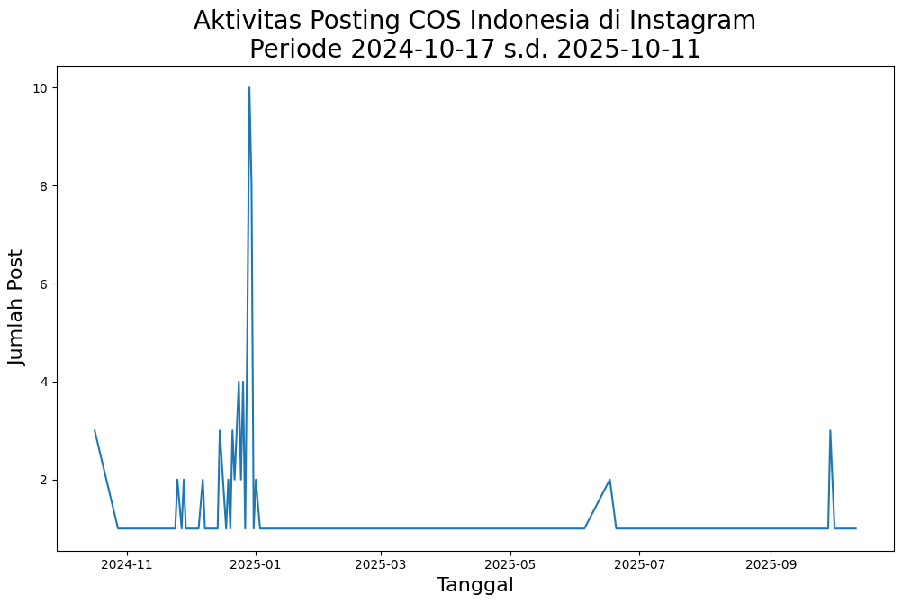

```python
#Grafik aktivitas posting
import matplotlib.pyplot as plt

# Pastikan kolom date sudah dalam format datetime
df_posts['date'] = pd.to_datetime(df_posts['timestamp']).dt.date

# Grafik aktivitas posting
df_posts['date'].value_counts().sort_index().plot(kind='line', figsize=(12,7))

# Ambil rentang waktu otomatis
start_date = df_posts['date'].min()
end_date = df_posts['date'].max()

plt.title(f'Aktivitas Posting COS Indonesia di Instagram\nPeriode {start_date} s.d. {end_date}', fontsize=20)
plt.xlabel('Tanggal', fontsize=16)
plt.ylabel('Jumlah Post', fontsize=16)
plt.grid(False)
plt.show()
```

# Insight: Aktivitas Postingan COS Indonesia di IG

# Kaitan dan Trend Komunikasi Digital

Fluktuasi ini menunjukkan bahwa COS Indonesia belum memiliki ritme posting yang konsisten sepanjang tahun. Konsentrasi posting di satu periode menandakan pola kampanye berbasis event, di mana aktivitas komunikasi meningkat pesat hanya saat menjelang atau selama pelaksanaan kegiatan. Di sisi lain, periode minim posting menandakan adanya celah komunikasi yang berpotensi menurunkan engagement audiens serta mengurangi kontinuitas awareness terhadap platform COS Indonesia sebagai wadah aspirasi digital.

# Rekomendasi

1. Perkuat Content Calendar Tahunan

Buat content plan bulanan yang tetap aktif meskipun di luar periode event besar. Ini menjaga algoritma dan keterlibatan audiens tetap stabil.

2 Diversifikasi Jenis Konten Saat tidak ada event besar, manfaatkan konten edukatif (misalnya: tips partisipasi publik, kutipan inspiratif, recap kegiatan) untuk menjaga relevansi audiens.

4 Bangun Narasi Keberlanjutan Program Posting tidak harus menunggu event besar — kamu bisa menyoroti impact story atau perjalanan relawan IOF agar pesan organisasi tetap hidup di benak publik.

# Kesimpulan

Aktivitas posting COS Indonesia di Instagram menunjukkan pola spike-based communication, dengan lonjakan intens saat periode kampanye besar dan jeda panjang di luar itu. Pola ini efektif untuk event exposure, namun belum mendukung brand consistency. Strategi yang disarankan adalah memperkuat ritme konten berkelanjutan dan menyebarkan momentum engagement secara lebih merata sepanjang tahun agar citra COS sebagai ruang aspirasi publik tetap aktif dan relevan di media sosial.

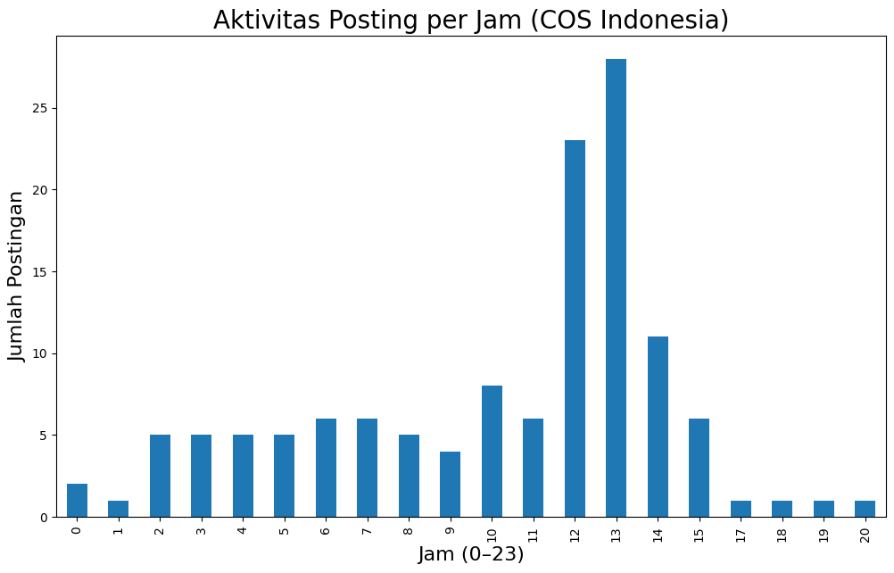

```python
# Analisis Aktivitas posting per jam (heatmap atau line chart)
import pandas as pd
import matplotlib.pyplot as plt
import seaborn as sns

# Pastikan timestamp sudah datetime
df_posts['timestamp'] = pd.to_datetime(df_posts['timestamp'])

# Buat kolom turunan waktu
df_posts['date'] = df_posts['timestamp'].dt.date
df_posts['hour'] = df_posts['timestamp'].dt.hour
df_posts['day'] = df_posts['timestamp'].dt.day_name()

# Aktivitas posting per jam
# Melihat jam berapa akun paling sering posting
plt.figure(figsize=(12,7))
df_posts['hour'].value_counts().sort_index().plot(kind='bar')
plt.title('Aktivitas Posting per Jam (COS Indonesia)', fontsize=20)
plt.xlabel('Jam (0–23)', fontsize=16)
plt.ylabel('Jumlah Postingan', fontsize=16)
plt.grid(False)
plt.show()
```

# Insight:

Pola ini mengindikasikan bahwa publikasi konten dilakukan secara terpusat dan administratif, bukan berbasis algoritma engagement audiens. Karena waktu unggahan bertepatan dengan jam kerja internal, kemungkinan besar unggahan dilakukan oleh admin atau tim internal saat jam kantor — bukan disesuaikan dengan perilaku aktif audiens di platform Instagram.

# Keterkaitan dengan Grafik Aktivitas Posting per Periode (Tahun 2024–2025)

Namun setelah periode IOF berlalu, baik dari segi frekuensi posting per tanggal maupun per jam, aktivitas komunikasi kembali menurun drastis — menandakan bahwa ritme unggahan masih event-centric, belum konsisten secara jangka panjang.

# Rekomendasi

1. Eksperimen Waktu Posting Berdasarkan Engagement Data

2. Gunakan Fitur Scheduling Tools

Jika posting dilakukan saat jam kerja internal, gunakan auto-scheduler tools (misal Meta Business Suite, Later, atau Buffer) agar konten bisa tayang di jam engagement puncak tanpa menambah workload admin.

3. Bangun Konsistensi Harian dan Mingguan

Alih-alih posting massal dalam satu periode, buat content cadence rutin (misal 3x/minggu di jam audiens aktif) untuk menjaga ritme algoritma dan awareness akun.

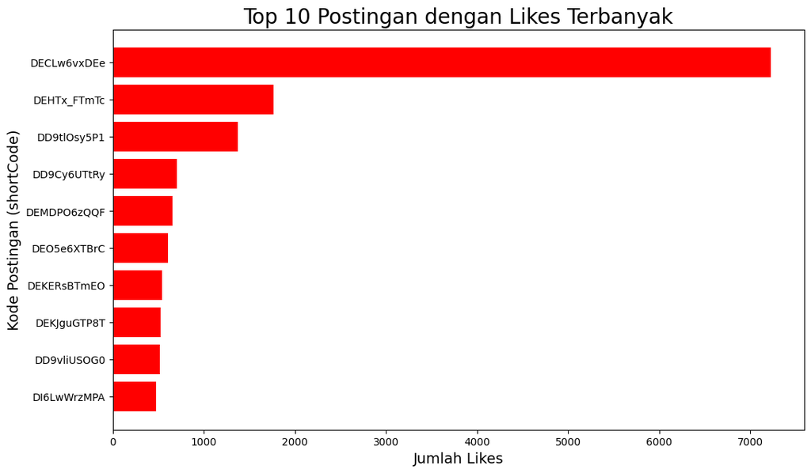

|  | shortCode | caption | likesCount | commentsCount | post_url |
| --- | --- | --- | --- | --- | --- |
| 73 | DECLw6vxDEe | Halo, #SobatParlemen! Sudah punya rencana untu... | 7233 | 249 | https://www.instagram.com/p/DECLw6vxDEe |
| 71 | DEHTx_FTmTc | Hai #SobatParlemen, bingung mau liburan akhir... | 1768 | 102 | https://www.instagram.com/p/DEHTx_FTmTc |
| 75 | DD9tlOsy5P1 | Halo, #SobatParlemen! Sudah punya rencana untu... | 1372 | 66 | https://www.instagram.com/p/DD9tlOsy5P1 |
| 80 | DD9Cy6UTtRy | Festival dari Rakyat untuk Rakyat!\n\nPertama ... | 704 | 36 | https://www.instagram.com/p/DD9Cy6UTtRy |
| 54 | DEMDPO6zQQF | Terima kasih sebesar-besarnya kepada #SobatPar... | 653 | 29 | https://www.instagram.com/p/DEMDPO6zQQF |
| 52 | DEO5e6XTBrC | Rangkaian Indonesia Opinion Festival (IOF) ke-... | 606 | 18 | https://www.instagram.com/p/DEO5e6XTBrC |
| 70 | DEKERsBTmEO | Hallo #SobatParlemen!\n\nTahu ga sih kalau Ind... | 541 | 13 | https://www.instagram.com/p/DEKERsBTmEO |
| 63 | DEKJguGTP8T | Halo #SobatParlemen! \n\nPada kegiatan Indones... | 522 | 26 | https://www.instagram.com/p/DEKJguGTP8T |
| 66 | DD9vliUSOG0 | Pendaftaran Peserta Offline IOF 2024 Telah Dib... | 515 | 22 | https://www.instagram.com/p/DD9vliUSOG0 |
| 24 | DI6LwWrzMPA | Meet Our Ambassadors!\n\nKami bangga memiliki ... | 478 | 17 | https://www.instagram.com/p/DI6LwWrzMPA |

```python
# Ambil 10 posting dengan likes terbanyak
top10_likes = df_posts.nlargest(10, 'likesCount')[['shortCode', 'caption', 'likesCount', 'commentsCount']]

# Tambahkan kolom URL Instagram
top10_likes['post_url'] = 'https://www.instagram.com/p/' + top10_likes['shortCode']

# Plot grafik
plt.figure(figsize=(12,7))
plt.barh(top10_likes['shortCode'], top10_likes['likesCount'], color='red')
plt.title('Top 10 Postingan dengan Likes Terbanyak', fontsize=20)
plt.xlabel('Jumlah Likes', fontsize=14)
plt.ylabel('Kode Postingan (shortCode)', fontsize=14)
plt.gca().invert_yaxis()
plt.show()

# Tampilkan tabel hasil
top10_likes
```

# Insight: Postingan dengan Like Terbanyak

Namun di sisi lain, posting dengan tema inti organisasi seperti demokrasi digital, festival aspirasi, dan ruang partisipasi publik (IOF) memperoleh engagement yang relatif lebih rendah. Hal ini menandakan bahwa pesan substantif COS Indonesia tentang civic engagement belum sepenuhnya tersampaikan secara emosional atau relatable bagi audiens umum. Audiens tampaknya lebih tertarik pada konten dengan figur, kolaborasi besar, atau call to action konkret (pendaftaran, pengumuman, rekrutmen) dibandingkan dengan pesan konseptual tentang demokrasi dan partisipasi.

# Rekomendasi

1. Gunakan pendekatan storytelling & human-interest

Ubah pesan demokrasi dan partisipasi menjadi kisah nyata — misalnya, pengalaman volunteer IOF, dampak kegiatan, atau profil anak muda yang menyuarakan aspirasi.

2. Optimalkan kolaborasi strategis tanpa kehilangan identitas

Kolaborasi dengan institusi publik atau figur dikenal terbukti meningkatkan engagement, tapi pastikan pesan COS tetap terwakili agar awareness terhadap brand voice tetap kuat.

3. Eksperimen format konten

Coba format visual yang lebih ringan dan interaktif (carousel edukatif, reels singkat, atau Q&A interaktif) untuk menjembatani topik berat seperti demokrasi dengan audiens Gen Z.

4. Gunakan momentum pendaftaran dan pengumuman sebagai entry point

Karena posting bertema rekrutmen dan pengumuman terbukti menarik, manfaatkan momen ini untuk soft educate audiens tentang nilai demokrasi dan civic participation di balik kegiatan tersebut.

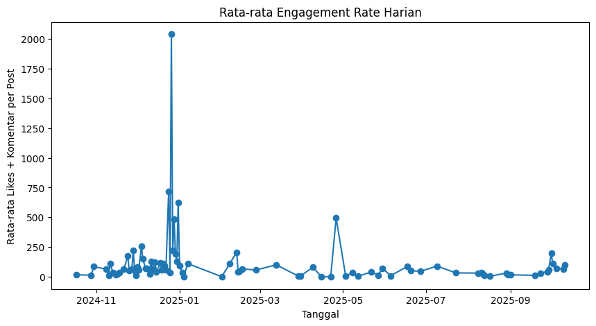

|  | date | engagement |
| --- | --- | --- |
| 83 | 2025-10-01 | 196.0 |
| 84 | 2025-10-02 | 113.0 |
| 85 | 2025-10-05 | 71.0 |
| 86 | 2025-10-10 | 65.0 |
| 87 | 2025-10-11 | 102.0 |

```python
# Rata-rata engagement rate per hari
# Engagement rate sederhana = (Likes + Komentar) / Total Post per hari
# Hitung engagement per post
df_posts['engagement'] = df_posts['likesCount'] + df_posts['commentsCount']

# Hitung rata-rata per hari
daily_engagement = df_posts.groupby('date')['engagement'].mean().reset_index()

plt.figure(figsize=(10,5))
plt.plot(daily_engagement['date'], daily_engagement['engagement'], marker='o')
plt.title('Rata-rata Engagement Rate Harian')
plt.xlabel('Tanggal')
plt.ylabel('Rata-rata Likes + Komentar per Post')
plt.grid(False)
plt.show()

daily_engagement.tail()
```

# Insight:

Ini menandakan bahwa strategi komunikasi masih berfokus pada event-driven engagement, belum beralih ke community-driven engagement yang berkelanjutan.

# Rekomendasi

1. Bangun kontinuitas narasi pasca-event

Setelah event besar seperti IOF, lanjutkan publikasi follow-up story — seperti pengalaman peserta, dampak kegiatan, atau recap highlight. Ini bisa memperpanjang umur engagement.

2. Kembangkan komunitas digital aktif

Buat engagement pillar rutin seperti diskusi ringan, kuis opini publik, atau “Sobat Democracy Corner” agar audiens tetap berinteraksi meskipun di luar periode event.

3.Eksperimen jenis konten interaktif Coba format seperti carousel edukatif, polling story, atau reels dengan format fast insight agar engagement lebih tersebar merata sepanjang tahun.

4.Gunakan momentum awal tahun sebagai benchmark Engagement tinggi pada Desember–Januari bisa dijadikan acuan — pelajari gaya konten, visual, dan tone komunikasi di periode itu untuk diterapkan secara konsisten di kampanye berikutnya.

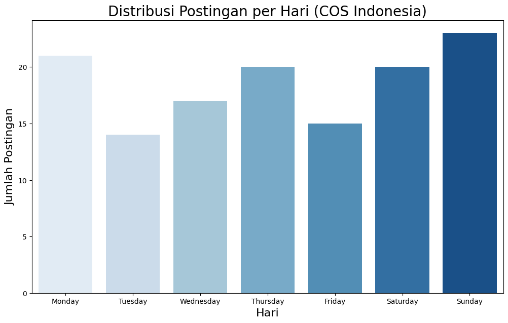

```python
# Distribusi posting per hari (Senin–Minggu)
import matplotlib.pyplot as plt
import seaborn as sns

# Pastikan kolom 'day' sudah ada
df_posts['timestamp'] = pd.to_datetime(df_posts['timestamp'])
df_posts['day'] = df_posts['timestamp'].dt.day_name()

# Urutan hari (biar nggak acak)
order_hari = ['Monday', 'Tuesday', 'Wednesday', 'Thursday', 'Friday', 'Saturday', 'Sunday']

# Plot
plt.figure(figsize=(12,7))
sns.countplot(data=df_posts, x='day', order=order_hari, palette='Blues')
plt.title('Distribusi Postingan per Hari (COS Indonesia)', fontsize=20)
plt.xlabel('Hari', fontsize=16)
plt.ylabel('Jumlah Postingan', fontsize=16)
plt.grid(False)
plt.show()
```

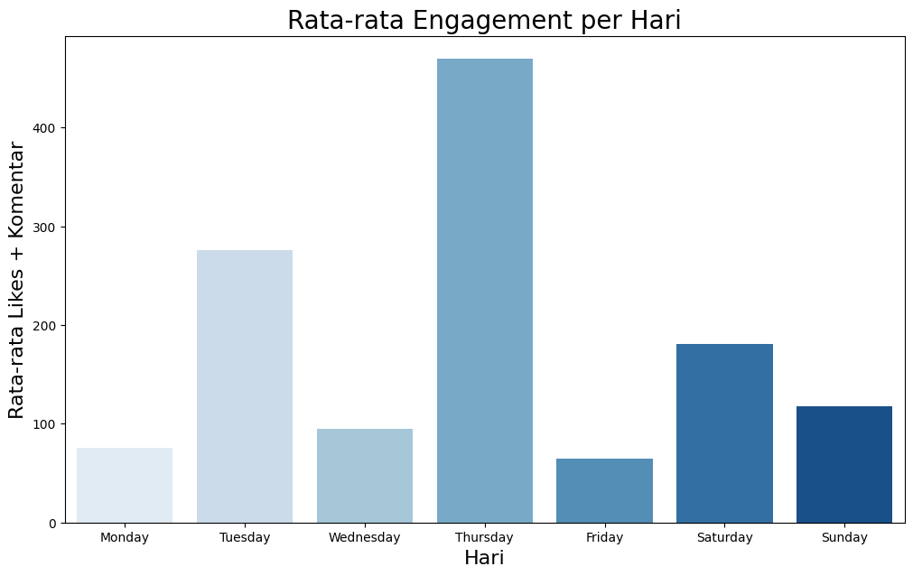

|  | day | engagement |
| --- | --- | --- |
| 0 | Monday | 75.761905 |
| 1 | Tuesday | 275.785714 |
| 2 | Wednesday | 95.176471 |
| 3 | Thursday | 469.400000 |
| 4 | Friday | 65.066667 |
| 5 | Saturday | 181.000000 |
| 6 | Sunday | 117.652174 |

```python
# Engage detail rata-rata per hari
df_posts['engagement'] = df_posts['likesCount'] + df_posts['commentsCount']

engagement_per_hari = (
    df_posts.groupby('day')['engagement']
    .mean()
    .reindex(order_hari)
    .reset_index()
)

plt.figure(figsize=(12,7))
sns.barplot(data=engagement_per_hari, x='day', y='engagement', palette='Blues')
plt.title('Rata-rata Engagement per Hari',fontsize=20)
plt.xlabel('Hari', fontsize=16)
plt.ylabel('Rata-rata Likes + Komentar',fontsize=16)
plt.grid(False)
plt.show()

engagement_per_hari
```

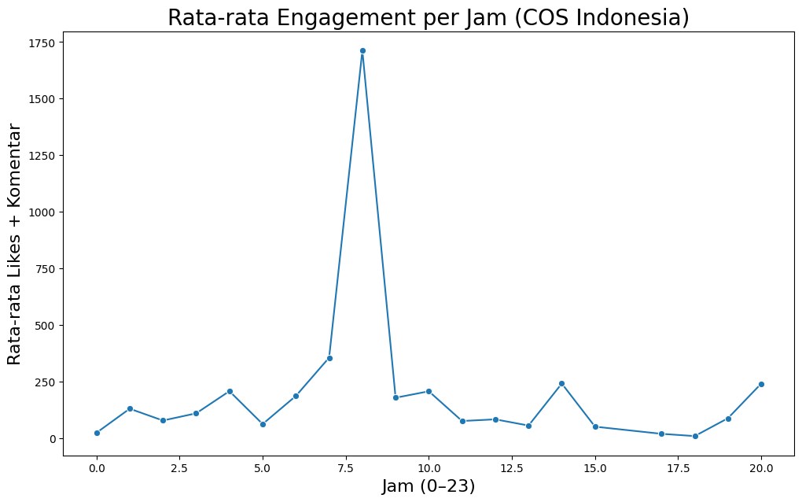

|  | hour | engagement |
| --- | --- | --- |
| 0 | 0 | 22.500000 |
| 1 | 1 | 129.000000 |
| 2 | 2 | 76.800000 |
| 3 | 3 | 108.600000 |
| 4 | 4 | 206.600000 |
| 5 | 5 | 61.200000 |
| 6 | 6 | 185.500000 |
| 7 | 7 | 354.833333 |
| 8 | 8 | 1712.600000 |
| 9 | 9 | 177.500000 |
| 10 | 10 | 206.125000 |
| 11 | 11 | 74.666667 |
| 12 | 12 | 82.000000 |
| 13 | 13 | 54.571429 |
| 14 | 14 | 240.272727 |
| 15 | 15 | 49.666667 |
| 16 | 17 | 18.000000 |
| 17 | 18 | 8.000000 |
| 18 | 19 | 87.000000 |
| 19 | 20 | 240.000000 |

```python
#Analisis Engagement per Jam
# “Jam berapa posting kamu paling banyak dapat likes & komentar?”
# Insight: Titik tertinggi = jam dengan engagement tertinggi → waktu terbaik buat posting
import matplotlib.pyplot as plt
import seaborn as sns

# Pastikan timestamp sudah datetime
df_posts['timestamp'] = pd.to_datetime(df_posts['timestamp'])

# Tambahkan kolom waktu & engagement
df_posts['hour'] = df_posts['timestamp'].dt.hour
df_posts['engagement'] = df_posts['likesCount'] + df_posts['commentsCount']

# Hitung rata-rata engagement per jam
engagement_per_hour = (
    df_posts.groupby('hour')['engagement']
    .mean()
    .reset_index()
)

# Plot
plt.figure(figsize=(12,7))
sns.lineplot(data=engagement_per_hour, x='hour', y='engagement', marker='o')
plt.title('Rata-rata Engagement per Jam (COS Indonesia)',fontsize=20)
plt.xlabel('Jam (0–23)',fontsize=16)
plt.ylabel('Rata-rata Likes + Komentar',fontsize=16)
plt.grid(False)
plt.show()

engagement_per_hour
```

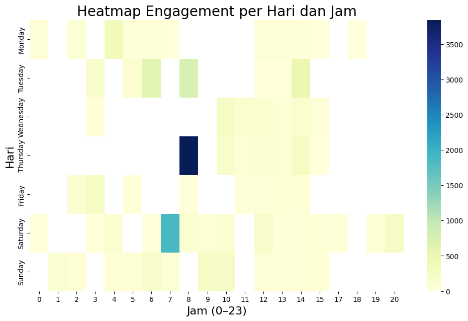

```python
# Analisis heatmap kombinasi hari vs jam
# Grup berdasarkan hari dan jam
df_posts['day'] = df_posts['timestamp'].dt.day_name()
order_hari = ['Monday', 'Tuesday', 'Wednesday', 'Thursday', 'Friday', 'Saturday', 'Sunday']

engagement_heatmap = (
    df_posts.groupby(['day', 'hour'])['engagement']
    .mean()
    .unstack()
    .reindex(order_hari)
)

plt.figure(figsize=(12,7))
sns.heatmap(engagement_heatmap, cmap='YlGnBu')
plt.title('Heatmap Engagement per Hari dan Jam',fontsize=20)
plt.xlabel('Jam (0–23)',fontsize=16)
plt.ylabel('Hari', fontsize=16)
plt.show()
```